# Sprawozdanie 3

Andrzej Miczek & Jakub Laszczyk

25.10.2023

# **1. Wybór i opis zestawu danych**

#### **Wybór**

Do wykonania tego zadania zdecydowaliśmy się wybrać zestaw danych **Herat.csv**, a dokładniej wersji wygenerowanej na podstawie poprzedniego zadania z zastąpionymi brakami na modstawie metody kNN - **Heart2.csv**.

#### **Opis i rodzaj zmiennych**

**Age** (Wiek): To jest zmienna ciągła, która określa wiek pacjenta. Może przyjmować wartości liczbowe reprezentujące wiek w latach.

**Sex** (Płeć): To jest zmienna kategoryczna, która określa płeć pacjenta. Zazwyczaj przyjmuje dwie wartości: “M” dla mężczyzn i “F” dla kobiet.

**RestingBP** (Ciśnienie spoczynkowe): To jest zmienna ciągła, która reprezentuje ciśnienie krwi pacjenta w spoczynku. Zwykle wyrażane w mm Hg (milimetrach słupa rtęci).

**Cholesterol** (Poziom cholesterolu): To jest zmienna ciągła, która określa poziom cholesterolu we krwi pacjenta. Zazwyczaj wyrażana w jednostkach, takich jak mg/dL.

**FastingBS** (Poziom glukozy na czczo): To jest zmienna kategoryczna, która określa, czy pacjent miał poziom glukozy na czczo powyżej pewnej wartości (np. “1” dla tak, “0” dla nie).

**MaxHR** (Maksymalne tętno): To jest zmienna ciągła, która reprezentuje maksymalne tętno pacjenta.

**ExerciseAngina** (Angina wysiłkowa): To jest zmienna kategoryczna, która określa, czy pacjent doświadczał duszności spowodowanej wysiłkiem (np. “1” dla tak, “0” dla nie).

**Oldpeak** (Obniżenie odcinka ST podczas wysiłku): To jest zmienna ciągła, która określa obniżenie odcinka ST w wyniku wysiłku fizycznego.

**ChestPainTypeASY** (Rodzaj bólu w klatce piersiowej: Asymptomatic): To jest zmienna kategoryczna, która określa rodzaj bólu w klatce piersiowej. Może mieć wartość “1” dla bólu typu “Asymptomatic” lub “0” dla innych rodzajów bólu.

**ChestPainTypeATA** (Rodzaj bólu w klatce piersiowej: Atypical angina): To jest zmienna kategoryczna, która określa rodzaj bólu w klatce piersiowej. Może mieć wartość “1” dla bólu typu “Atypical angina” lub “0” dla innych rodzajów bólu.

**ChestPainTypeNAP** (Rodzaj bólu w klatce piersiowej: Non-anginal pain): To jest zmienna kategoryczna, która określa rodzaj bólu w klatce piersiowej. Może mieć wartość “1” dla bólu typu “Non-anginal pain” lub “0” dla innych rodzajów bólu.

**RestingECGLVH** (Wynik elektrokardiogramu w spoczynku: Left ventricular hypertrophy): To jest zmienna kategoryczna, która określa wynik elektrokardiogramu w spoczynku. Może mieć wartość “1” dla “Left ventricular hypertrophy” lub “0” dla innego wyniku.

**RestingECGNormal** (Wynik elektrokardiogramu w spoczynku: Normal): To jest zmienna kategoryczna, która określa wynik elektrokardiogramu w spoczynku. Może mieć wartość “1” dla “Normal” lub “0” dla innego wyniku.

**STSlopeDown** (Nachylenie odcinka ST: Down-sloping): To jest zmienna kategoryczna, która określa nachylenie odcinka ST. Może mieć wartość “1” dla “Down-sloping” lub “0” dla innego nachylenia.

**STSlopeFlat** (Nachylenie odcinka ST: Flat): To jest zmienna kategoryczna, która określa nachylenie odcinka ST. Może mieć wartość “1” dla “Flat” lub “0” dla innego nachylenia.

**heartDisease** (Choroba serca): To jest zmienna kategoryczna, która określa obecność lub brak choroby serca. Zazwyczaj przyjmuje wartość “1” dla obecności choroby serca i “0” dla jej braku.

Zmienna “heartDisease” jest w naszym przypadku zmienną docelową lub zmienną wynikową, którą można próbować przewidywać na podstawie innych zmiennych w zestawie danych, przy pomocy modelowania predykcyjnego. Reszta zmiennych stanowi potencjalne cechy lub zmienne objaśniające.

```r
dane <-  read.csv("Heart2.csv", sep=";")
```

[output not shown]

# **2. Wykorzystanie prostego drzewa decyzyjnego do predykcji wartości zmiennej wynikowej.**

#### **Weryfikacja jak poziom przycięcie drzewa wpływa na uzyskiwane wyniki.**

```r
library(caret)
library(rpart.plot)
library(mlr)
library(pROC)
library(rpart)
library(adabag)
```

```r
dane <-  read.csv("Heart2.csv", sep=";")
```

Ze względu na skłonność algorytmów drzew decyzyjnych do przeuczenia się, czyli brakiem zdolności modelu do uogólnienia, co wpływa na niska jakość predykcji. Aby uniknąć nadmiernego dopasowania w trakcie tworzenia drzewa, ważne jest, aby przestrzegać zasady dążenia do konstruowania drzewa o jak najmniejszej złożoności. Popularną metodą zwalczająca zjawisko przeuczenia jest przycinanie drzewa. Najpopularniejsza metoda jest przycinanie wsteczne, polega ono na generowaniu dużego, dobrze dopasowanego do danych drzewa, a następnie usuwanie od dołu najmniej efektywnych gałęzi. Przycinanie drzewa oprócz zwalczania zjawiska przeuczenia, poprawia interpretowalność modelu dla użytkownika oraz zmniejsza złożoność obliczeniową co prowadzi do mniejszego czasu trenowania. W pierwszym kroku budujemy jak najbardziej rozbudowane drzewo (cp=0), a nastepnie przycinamy je za pomoca poziomu cp wyznaczonego na podstawie minimalizowania błędu walidacji krzyżowej.

```r
#Hyperparameter Tuning training with mlr
getParamSet("classif.rpart")
```

```
##                    Type len  Def   Constr Req Tunable Trafo
## minsplit        integer   -   20 1 to Inf   -    TRUE     -
## minbucket       integer   -    - 1 to Inf   -    TRUE     -
## cp              numeric   - 0.01   0 to 1   -    TRUE     -
## maxcompete      integer   -    4 0 to Inf   -    TRUE     -
## maxsurrogate    integer   -    5 0 to Inf   -    TRUE     -
## usesurrogate   discrete   -    2    0,1,2   -    TRUE     -
## surrogatestyle discrete   -    0      0,1   -    TRUE     -
## maxdepth        integer   -   30  1 to 30   -    TRUE     -
## xval            integer   -   10 0 to Inf   -   FALSE     -
## parms           untyped   -    -        -   -    TRUE     -
```

```r
traintask <- makeClassifTask(
  data=train_set,
  target="heartDisease"
)
# Define Grid
control_grid = makeTuneControlGrid()
# Define Cross Validation
resample = makeResampleDesc("CV",iter = 5,predict = "both")
# Define Measure
measure = acc
learner <- makeLearner("classif.rpart", predict.type = "prob", parms = list(split = "information"))

param_grid <- makeParamSet(
  makeDiscreteParam("maxdepth", values=2:7),
  makeDiscreteParam("cp", values = 0),
  makeDiscreteParam("minsplit", values=c(2,5,10,15,20)),
  makeDiscreteParam('xval',value =10)
)
```

```r
dt_tuneparam_multi <- tuneParams(learner=learner,
                                 task=traintask,
                                 resampling = resample,
                                 measures = measure,
                                 par.set=param_grid,
                                 control=control_grid,
                                 show.info = TRUE)
```

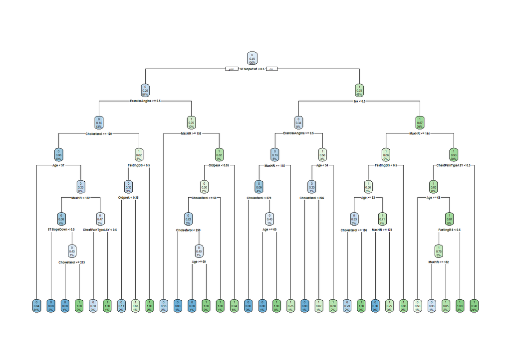

```r
# Extracting best Parameters from Multi Search
best_params = setHyperPars(
  makeLearner("classif.rpart", predict.type = "prob"),
  par.vals = dt_tuneparam_multi$x
)

best_model_multi <- mlr::train(best_params, traintask)
best_tree_model <- best_model_multi$learner.model
rpart.plot(best_tree_model)
```

```r
predicted2 <- predict(best_tree_model, newdata = test_set, type = "class")
confusionMatrix(predicted2, test_set$heartDisease)
```

```
## Confusion Matrix and Statistics
##
##           Reference
## Prediction  0  1
##          0 98 25
##          1 20 99
##
##                Accuracy : 0.814
##                  95% CI : (0.7592, 0.861)
##     No Information Rate : 0.5124
##     P-Value [Acc > NIR] : <2e-16
##
##                   Kappa : 0.6283
##
##  Mcnemar's Test P-Value : 0.551
##
##             Sensitivity : 0.8305
##             Specificity : 0.7984
##          Pos Pred Value : 0.7967
##          Neg Pred Value : 0.8319
##              Prevalence : 0.4876
##          Detection Rate : 0.4050
##    Detection Prevalence : 0.5083
##       Balanced Accuracy : 0.8144
##
##        'Positive' Class : 0
##
```

```r
#przycinanie
best_tree_model$cptable
```

```
##              CP nsplit rel error    xerror       xstd
## 1  0.5281690141      0 1.0000000 1.0000000 0.04224945
## 2  0.0845070423      1 0.4718310 0.4718310 0.03570540
## 3  0.0492957746      2 0.3873239 0.4471831 0.03503446
## 4  0.0246478873      3 0.3380282 0.3697183 0.03262688
## 5  0.0211267606      4 0.3133803 0.3521127 0.03200913
## 6  0.0176056338      5 0.2922535 0.3204225 0.03082208
## 7  0.0105633803      6 0.2746479 0.3274648 0.03109463
## 8  0.0088028169      8 0.2535211 0.3239437 0.03095901
## 9  0.0070422535     10 0.2359155 0.3380282 0.03149392
## 10 0.0058685446     12 0.2218310 0.3415493 0.03162453
## 11 0.0046948357     17 0.1901408 0.3133803 0.03054428
## 12 0.0035211268     20 0.1760563 0.3063380 0.03026108
## 13 0.0008802817     27 0.1514085 0.3204225 0.03082208
## 14 0.0000000000     31 0.1478873 0.3345070 0.03136207
```

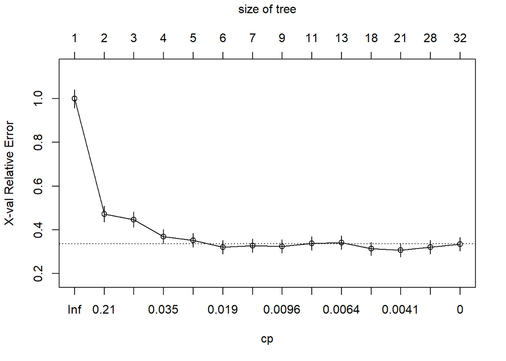

```r
best_cp <- best_tree_model$cptable[which.min(best_tree_model$cptable[,"xerror"]),"CP"]
plotcp(best_tree_model)
```

```r
# Teraz możemy przyciąć nasze drzewo
pruned_tree1 <- prune(best_tree_model, cp = 0.528169014)
pruned_tree2 <- prune(best_tree_model, cp = 0.049295775)
pruned_tree3 <- prune(best_tree_model, cp = 0.017605634)
pruned_tree4 <- prune(best_tree_model, cp = 0.000000000)
#testowanie przycietego drzewa na zbiorze treningowym
predicted3 <- predict(pruned_tree1, newdata = train_set, type = "class")
confusionMatrix(predicted3, train_set$heartDisease)
```

```
## Confusion Matrix and Statistics
##
##           Reference
## Prediction   0   1
##          0 234  76
##          1  58 208
##
##                Accuracy : 0.7674
##                  95% CI : (0.7307, 0.8013)
##     No Information Rate : 0.5069
##     P-Value [Acc > NIR] : <2e-16
##
##                   Kappa : 0.5342
##
##  Mcnemar's Test P-Value : 0.1419
##
##             Sensitivity : 0.8014
##             Specificity : 0.7324
##          Pos Pred Value : 0.7548
##          Neg Pred Value : 0.7820
##              Prevalence : 0.5069
##          Detection Rate : 0.4062
##    Detection Prevalence : 0.5382
##       Balanced Accuracy : 0.7669
##
##        'Positive' Class : 0
##
```

```r
# Testowanie przyciętego drzewa na zbiorze testowym
predicted4 <- predict(pruned_tree1, newdata = test_set, type = "class")
confusionMatrix(predicted4, test_set$heartDisease)
```

```
## Confusion Matrix and Statistics
##
##           Reference
## Prediction  0  1
##          0 97 26
##          1 21 98
##
##                Accuracy : 0.8058
##                  95% CI : (0.7502, 0.8537)
##     No Information Rate : 0.5124
##     P-Value [Acc > NIR] : <2e-16
##
##                   Kappa : 0.6117
##
##  Mcnemar's Test P-Value : 0.5596
##
##             Sensitivity : 0.8220
##             Specificity : 0.7903
##          Pos Pred Value : 0.7886
##          Neg Pred Value : 0.8235
##              Prevalence : 0.4876
##          Detection Rate : 0.4008
##    Detection Prevalence : 0.5083
##       Balanced Accuracy : 0.8062
##
##        'Positive' Class : 0
##
```

```r
#testowanie przycietego drzewa na zbiorze treningowym
predicted3 <- predict(pruned_tree2, newdata = train_set, type = "class")
confusionMatrix(predicted3, train_set$heartDisease)
```

```
## Confusion Matrix and Statistics
##
##           Reference
## Prediction   0   1
##          0 216  34
##          1  76 250
##
##                Accuracy : 0.809
##                  95% CI : (0.7745, 0.8403)
##     No Information Rate : 0.5069
##     P-Value [Acc > NIR] : < 2.2e-16
##
##                   Kappa : 0.6188
##
##  Mcnemar's Test P-Value : 9.26e-05
##
##             Sensitivity : 0.7397
##             Specificity : 0.8803
##          Pos Pred Value : 0.8640
##          Neg Pred Value : 0.7669
##              Prevalence : 0.5069
##          Detection Rate : 0.3750
##    Detection Prevalence : 0.4340
##       Balanced Accuracy : 0.8100
##
##        'Positive' Class : 0
##
```

```r
# Testowanie przyciętego drzewa na zbiorze testowym
predicted4 <- predict(pruned_tree2, newdata = test_set, type = "class")
confusionMatrix(predicted4, test_set$heartDisease)
```

```
## Confusion Matrix and Statistics
##
##           Reference
## Prediction   0   1
##          0  86   9
##          1  32 115
##
##                Accuracy : 0.8306
##                  95% CI : (0.7773, 0.8756)
##     No Information Rate : 0.5124
##     P-Value [Acc > NIR] : < 2.2e-16
##
##                   Kappa : 0.6593
##
##  Mcnemar's Test P-Value : 0.0005908
##
##             Sensitivity : 0.7288
##             Specificity : 0.9274
##          Pos Pred Value : 0.9053
##          Neg Pred Value : 0.7823
##              Prevalence : 0.4876
##          Detection Rate : 0.3554
##    Detection Prevalence : 0.3926
##       Balanced Accuracy : 0.8281
##
##        'Positive' Class : 0
##
```

```r
#testowanie przycietego drzewa na zbiorze treningowym
predicted3 <- predict(pruned_tree3, newdata = train_set, type = "class")
confusionMatrix(predicted3, train_set$heartDisease)
```

```
## Confusion Matrix and Statistics
##
##           Reference
## Prediction   0   1
##          0 244  35
##          1  48 249
##
##                Accuracy : 0.8559
##                  95% CI : (0.8245, 0.8836)
##     No Information Rate : 0.5069
##     P-Value [Acc > NIR] : <2e-16
##
##                   Kappa : 0.7119
##
##  Mcnemar's Test P-Value : 0.1878
##
##             Sensitivity : 0.8356
##             Specificity : 0.8768
##          Pos Pred Value : 0.8746
##          Neg Pred Value : 0.8384
##              Prevalence : 0.5069
##          Detection Rate : 0.4236
##    Detection Prevalence : 0.4844
##       Balanced Accuracy : 0.8562
##
##        'Positive' Class : 0
##
```

```r
# Testowanie przyciętego drzewa na zbiorze testowym
predicted4 <- predict(pruned_tree3, newdata = test_set, type = "class")
confusionMatrix(predicted4, test_set$heartDisease)
```

```
## Confusion Matrix and Statistics
##
##           Reference
## Prediction   0   1
##          0  92  18
##          1  26 106
##
##                Accuracy : 0.8182
##                  95% CI : (0.7637, 0.8647)
##     No Information Rate : 0.5124
##     P-Value [Acc > NIR] : <2e-16
##
##                   Kappa : 0.6355
##
##  Mcnemar's Test P-Value : 0.2913
##
##             Sensitivity : 0.7797
##             Specificity : 0.8548
##          Pos Pred Value : 0.8364
##          Neg Pred Value : 0.8030
##              Prevalence : 0.4876
##          Detection Rate : 0.3802
##    Detection Prevalence : 0.4545
##       Balanced Accuracy : 0.8172
##
##        'Positive' Class : 0
##
```

```r
#testowanie przycietego drzewa na zbiorze treningowym
predicted3 <- predict(pruned_tree4, newdata = train_set, type = "class")
confusionMatrix(predicted3, train_set$heartDisease)
```

```
## Confusion Matrix and Statistics
##
##           Reference
## Prediction   0   1
##          0 271  21
##          1  21 263
##
##                Accuracy : 0.9271
##                  95% CI : (0.9027, 0.9469)
##     No Information Rate : 0.5069
##     P-Value [Acc > NIR] : <2e-16
##
##                   Kappa : 0.8541
##
##  Mcnemar's Test P-Value : 1
##
##             Sensitivity : 0.9281
##             Specificity : 0.9261
##          Pos Pred Value : 0.9281
##          Neg Pred Value : 0.9261
##              Prevalence : 0.5069
##          Detection Rate : 0.4705
##    Detection Prevalence : 0.5069
##       Balanced Accuracy : 0.9271
##
##        'Positive' Class : 0
##
```

```r
# Testowanie przyciętego drzewa na zbiorze testowym
predicted4 <- predict(pruned_tree4, newdata = test_set, type = "class")
confusionMatrix(predicted4, test_set$heartDisease)
```

```
## Confusion Matrix and Statistics
##
##           Reference
## Prediction  0  1
##          0 98 25
##          1 20 99
##
##                Accuracy : 0.814
##                  95% CI : (0.7592, 0.861)
##     No Information Rate : 0.5124
##     P-Value [Acc > NIR] : <2e-16
##
##                   Kappa : 0.6283
##
##  Mcnemar's Test P-Value : 0.551
##
##             Sensitivity : 0.8305
##             Specificity : 0.7984
##          Pos Pred Value : 0.7967
##          Neg Pred Value : 0.8319
##              Prevalence : 0.4876
##          Detection Rate : 0.4050
##    Detection Prevalence : 0.5083
##       Balanced Accuracy : 0.8144
##
##        'Positive' Class : 0
##
```

#### **Weryfikacja jak wybór reguły klasyfikacyjnej (indeks Giniego, entropia) wpływa na uzyskiwane wyniki.**

Kryterium podziału służy do znalezienia optymalnego podziału zbioru w węźle, w taki sposób aby zwiększyć jednorodność klas, i poprawić zdolność do predykcji. Kryterium podziału określane tez testem związane jest z atrybutami naszego modelu oraz przyjmowanymi przez nie wartościami. Metody które możemy wykorzystać do podziału w drzewach klasyfikacyjnych to: Współczynnik Giniego oraz entropia.

###### **Współczynnik Giniego**

```r
#Hyperparameter Tuning training with mlr
getParamSet("classif.rpart")
```

```
##                    Type len  Def   Constr Req Tunable Trafo
## minsplit        integer   -   20 1 to Inf   -    TRUE     -
## minbucket       integer   -    - 1 to Inf   -    TRUE     -
## cp              numeric   - 0.01   0 to 1   -    TRUE     -
## maxcompete      integer   -    4 0 to Inf   -    TRUE     -
## maxsurrogate    integer   -    5 0 to Inf   -    TRUE     -
## usesurrogate   discrete   -    2    0,1,2   -    TRUE     -
## surrogatestyle discrete   -    0      0,1   -    TRUE     -
## maxdepth        integer   -   30  1 to 30   -    TRUE     -
## xval            integer   -   10 0 to Inf   -   FALSE     -
## parms           untyped   -    -        -   -    TRUE     -
```

```r
traintask <- makeClassifTask(
  data=train_set,
  target="heartDisease"
)
# Define Grid
control_grid = makeTuneControlGrid()
# Define Cross Validation
resample = makeResampleDesc("CV",iter = 5,predict = "both")
# Define Measure
measure = acc
learner <- makeLearner("classif.rpart", predict.type = "prob", parms = list(split = "gini"))

param_grid <- makeParamSet(
  makeDiscreteParam("maxdepth", values=2:7),
  makeDiscreteParam("cp", values = 0),
  makeDiscreteParam("minsplit", values=c(2,5,10,15,20)),
  makeDiscreteParam('xval',value =10)
)
```

```r
dt_tuneparam_multi <- tuneParams(learner=learner,
                                 task=traintask,
                                 resampling = resample,
                                 measures = measure,
                                 par.set=param_grid,
                                 control=control_grid,
                                 show.info = TRUE)
```

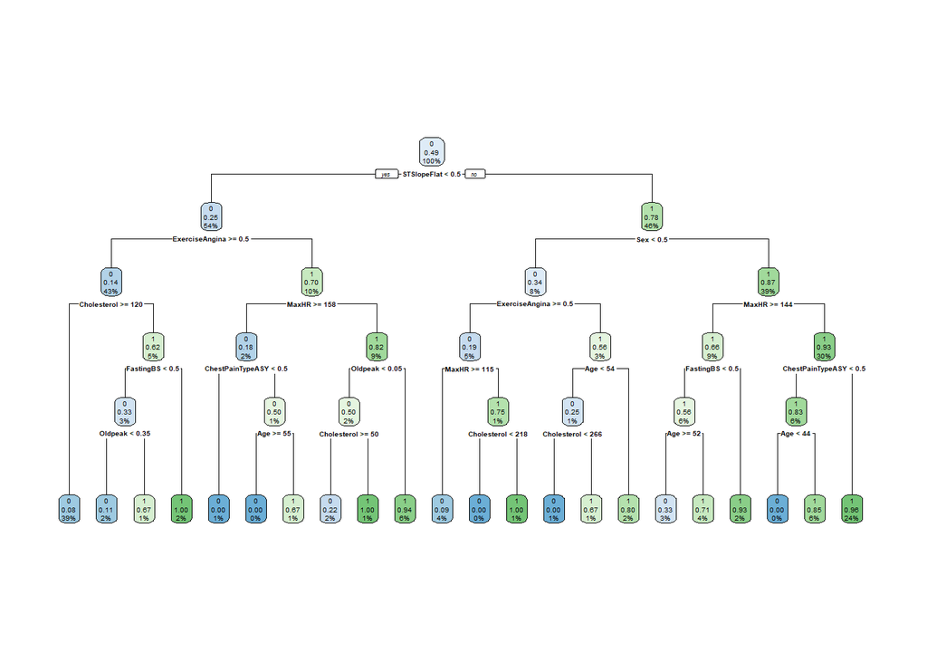

```r
# Extracting best Parameters from Multi Search
best_params = setHyperPars(
  makeLearner("classif.rpart", predict.type = "prob"),
  par.vals = dt_tuneparam_multi$x
)

best_model_multi <- mlr::train(best_params, traintask)
best_tree_model <- best_model_multi$learner.model

rpart.plot::rpart.plot(best_tree_model)
```

```r
predicted2 <- predict(best_tree_model, newdata = test_set, type = "class")

confusionMatrix(predicted2, test_set$heartDisease)
```

```
## Confusion Matrix and Statistics
##
##           Reference
## Prediction  0  1
##          0 99 25
##          1 19 99
##
##                Accuracy : 0.8182
##                  95% CI : (0.7637, 0.8647)
##     No Information Rate : 0.5124
##     P-Value [Acc > NIR] : <2e-16
##
##                   Kappa : 0.6366
##
##  Mcnemar's Test P-Value : 0.451
##
##             Sensitivity : 0.8390
##             Specificity : 0.7984
##          Pos Pred Value : 0.7984
##          Neg Pred Value : 0.8390
##              Prevalence : 0.4876
##          Detection Rate : 0.4091
##    Detection Prevalence : 0.5124
##       Balanced Accuracy : 0.8187
##
##        'Positive' Class : 0
##
```

```r
probabilities <- predict(best_tree_model, newdata = test_set, type = "prob")[,2]
roc_obj <- roc(test_set$heartDisease, probabilities)
auc <- round(auc(test_set$heartDisease, probabilities),4)
# Przycinanie
best_tree_model$cptable
```

```
##             CP nsplit rel error    xerror       xstd
## 1  0.528169014      0 1.0000000 1.0000000 0.04224945
## 2  0.084507042      1 0.4718310 0.4718310 0.03570540
## 3  0.049295775      2 0.3873239 0.3978873 0.03355831
## 4  0.024647887      3 0.3380282 0.3485915 0.03188212
## 5  0.021126761      4 0.3133803 0.3415493 0.03162453
## 6  0.017605634      5 0.2922535 0.3239437 0.03095901
## 7  0.010563380      6 0.2746479 0.3028169 0.03011741
## 8  0.008802817      8 0.2535211 0.2852113 0.02937755
## 9  0.007042254     10 0.2359155 0.2922535 0.02967788
## 10 0.005868545     12 0.2218310 0.3028169 0.03011741
## 11 0.003521127     15 0.2042254 0.3098592 0.03040337
## 12 0.001760563     17 0.1971831 0.3169014 0.03068385
## 13 0.000000000     21 0.1901408 0.3309859 0.03122898
```

```r
best_cp <- best_tree_model$cptable[which.min(best_tree_model$cptable[,"xerror"]),"CP"]
```

[figure not shown]

```r
# Teraz możemy przyciąć nasze drzewo
pruned_tree <- rpart::prune(best_tree_model, cp = best_cp)
print(pruned_tree)
```

```
## n= 576
##
## node), split, n, loss, yval, (yprob)
##       * denotes terminal node
##
##  1) root 576 284 0 (0.50694444 0.49305556)
##    2) STSlopeFlat< 0.5 310  76 0 (0.75483871 0.24516129)
##      4) ExerciseAngina>=0.5 250  34 0 (0.86400000 0.13600000)
##        8) Cholesterol>=119.5 224  18 0 (0.91964286 0.08035714) *
##        9) Cholesterol< 119.5 26  10 1 (0.38461538 0.61538462)
##         18) FastingBS< 0.5 15   5 0 (0.66666667 0.33333333) *
##         19) FastingBS>=0.5 11   0 1 (0.00000000 1.00000000) *
##      5) ExerciseAngina< 0.5 60  18 1 (0.30000000 0.70000000)
##       10) MaxHR>=157.5 11   2 0 (0.81818182 0.18181818) *
##       11) MaxHR< 157.5 49   9 1 (0.18367347 0.81632653) *
##    3) STSlopeFlat>=0.5 266  58 1 (0.21804511 0.78195489)
##      6) Sex< 0.5 44  15 0 (0.65909091 0.34090909)
##       12) ExerciseAngina>=0.5 26   5 0 (0.80769231 0.19230769) *
##       13) ExerciseAngina< 0.5 18   8 1 (0.44444444 0.55555556)
##         26) Age< 54 8   2 0 (0.75000000 0.25000000) *
##         27) Age>=54 10   2 1 (0.20000000 0.80000000) *
##      7) Sex>=0.5 222  29 1 (0.13063063 0.86936937) *
```

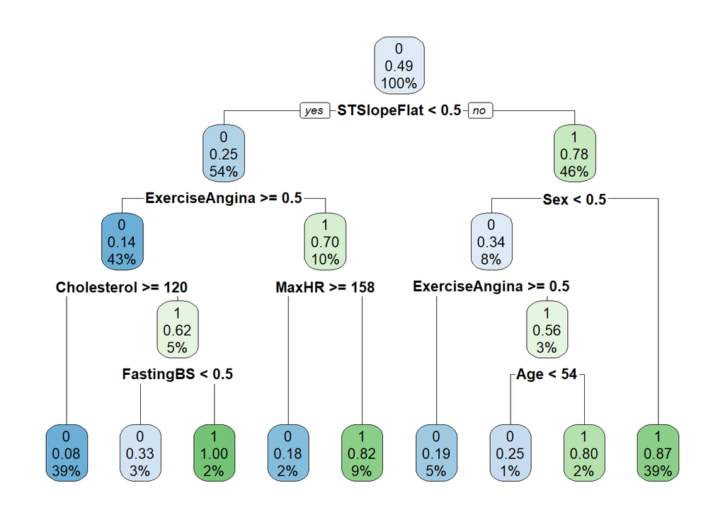

```r
rpart.plot(pruned_tree,roundint = FALSE)
```

```r
#testowanie przycietego drzewa na zbiorze treningowym
predicted3 <- predict(pruned_tree, newdata = train_set, type = "class")
confusionMatrix(predicted3, train_set$heartDisease)
```

```
## Confusion Matrix and Statistics
##
##           Reference
## Prediction   0   1
##          0 252  32
##          1  40 252
##
##                Accuracy : 0.875
##                  95% CI : (0.8452, 0.9009)
##     No Information Rate : 0.5069
##     P-Value [Acc > NIR] : <2e-16
##
##                   Kappa : 0.75
##
##  Mcnemar's Test P-Value : 0.4094
##
##             Sensitivity : 0.8630
##             Specificity : 0.8873
##          Pos Pred Value : 0.8873
##          Neg Pred Value : 0.8630
##              Prevalence : 0.5069
##          Detection Rate : 0.4375
##    Detection Prevalence : 0.4931
##       Balanced Accuracy : 0.8752
##
##        'Positive' Class : 0
##
```

```r
# Testowanie przyciętego drzewa na zbiorze testowym
predicted4 <- predict(pruned_tree, newdata = test_set, type = "class")
confusionMatrix(predicted4, test_set$heartDisease)
```

```
## Confusion Matrix and Statistics
##
##           Reference
## Prediction   0   1
##          0  95  14
##          1  23 110
##
##                Accuracy : 0.8471
##                  95% CI : (0.7955, 0.89)
##     No Information Rate : 0.5124
##     P-Value [Acc > NIR] : <2e-16
##
##                   Kappa : 0.6935
##
##  Mcnemar's Test P-Value : 0.1884
##
##             Sensitivity : 0.8051
##             Specificity : 0.8871
##          Pos Pred Value : 0.8716
##          Neg Pred Value : 0.8271
##              Prevalence : 0.4876
##          Detection Rate : 0.3926
##    Detection Prevalence : 0.4504
##       Balanced Accuracy : 0.8461
##
##        'Positive' Class : 0
##
```

###### **Entropia**

```r
#Hyperparameter Tuning training with mlr
getParamSet("classif.rpart")
```

```
##                    Type len  Def   Constr Req Tunable Trafo
## minsplit        integer   -   20 1 to Inf   -    TRUE     -
## minbucket       integer   -    - 1 to Inf   -    TRUE     -
## cp              numeric   - 0.01   0 to 1   -    TRUE     -
## maxcompete      integer   -    4 0 to Inf   -    TRUE     -
## maxsurrogate    integer   -    5 0 to Inf   -    TRUE     -
## usesurrogate   discrete   -    2    0,1,2   -    TRUE     -
## surrogatestyle discrete   -    0      0,1   -    TRUE     -
## maxdepth        integer   -   30  1 to 30   -    TRUE     -
## xval            integer   -   10 0 to Inf   -   FALSE     -
## parms           untyped   -    -        -   -    TRUE     -
```

```r
traintask <- makeClassifTask(
  data=train_set,
  target="heartDisease"
)
# Define Grid
control_grid = makeTuneControlGrid()
# Define Cross Validation
resample = makeResampleDesc("CV",iter = 5,predict = "both")
# Define Measure
measure = acc
learner <- makeLearner("classif.rpart", predict.type = "prob", parms = list(split = "information"))

param_grid <- makeParamSet(
  makeDiscreteParam("maxdepth", values=2:7),
  makeDiscreteParam("cp", values = 0),
  makeDiscreteParam("minsplit", values=c(2,5,10,15,20)),
  makeDiscreteParam('xval',value =10)
)
```

```r
dt_tuneparam_multi <- tuneParams(learner=learner,
                                 task=traintask,
                                 resampling = resample,
                                 measures = measure,
                                 par.set=param_grid,
                                 control=control_grid,
                                 show.info = TRUE)
```

```r
# Extracting best Parameters from Multi Search
best_params = setHyperPars(
  makeLearner("classif.rpart", predict.type = "prob"),
  par.vals = dt_tuneparam_multi$x
)

best_model_multi <- mlr::train(best_params, traintask)
best_tree_model <- best_model_multi$learner.model
rpart.plot(best_tree_model)
```

[output not shown]

```r
predicted2 <- predict(best_tree_model, newdata = test_set, type = "class")
confusionMatrix(predicted2, test_set$heartDisease)
```

```
## Confusion Matrix and Statistics
##
##           Reference
## Prediction   0   1
##          0  95  11
##          1  23 113
##
##                Accuracy : 0.8595
##                  95% CI : (0.8092, 0.9007)
##     No Information Rate : 0.5124
##     P-Value [Acc > NIR] : < 2e-16
##
##                   Kappa : 0.7181
##
##  Mcnemar's Test P-Value : 0.05923
##
##             Sensitivity : 0.8051
##             Specificity : 0.9113
##          Pos Pred Value : 0.8962
##          Neg Pred Value : 0.8309
##              Prevalence : 0.4876
##          Detection Rate : 0.3926
##    Detection Prevalence : 0.4380
##       Balanced Accuracy : 0.8582
##
##        'Positive' Class : 0
##
```

```r
probabilities <- predict(best_tree_model, newdata = test_set, type = "prob")[,2]
roc_obj <- roc(test_set$heartDisease, probabilities)
auc <- round(auc(test_set$heartDisease, probabilities),4)
#przycinanie
best_tree_model$cptable
```

```
##            CP nsplit rel error    xerror       xstd
## 1 0.528169014      0 1.0000000 1.0880282 0.04214104
## 2 0.084507042      1 0.4718310 0.4718310 0.03570540
## 3 0.049295775      2 0.3873239 0.4436620 0.03493510
## 4 0.024647887      3 0.3380282 0.3697183 0.03262688
## 5 0.021126761      4 0.3133803 0.3661972 0.03250559
## 6 0.017605634      5 0.2922535 0.3556338 0.03213497
## 7 0.007042254      6 0.2746479 0.3274648 0.03109463
## 8 0.000000000      7 0.2676056 0.3380282 0.03149392
```

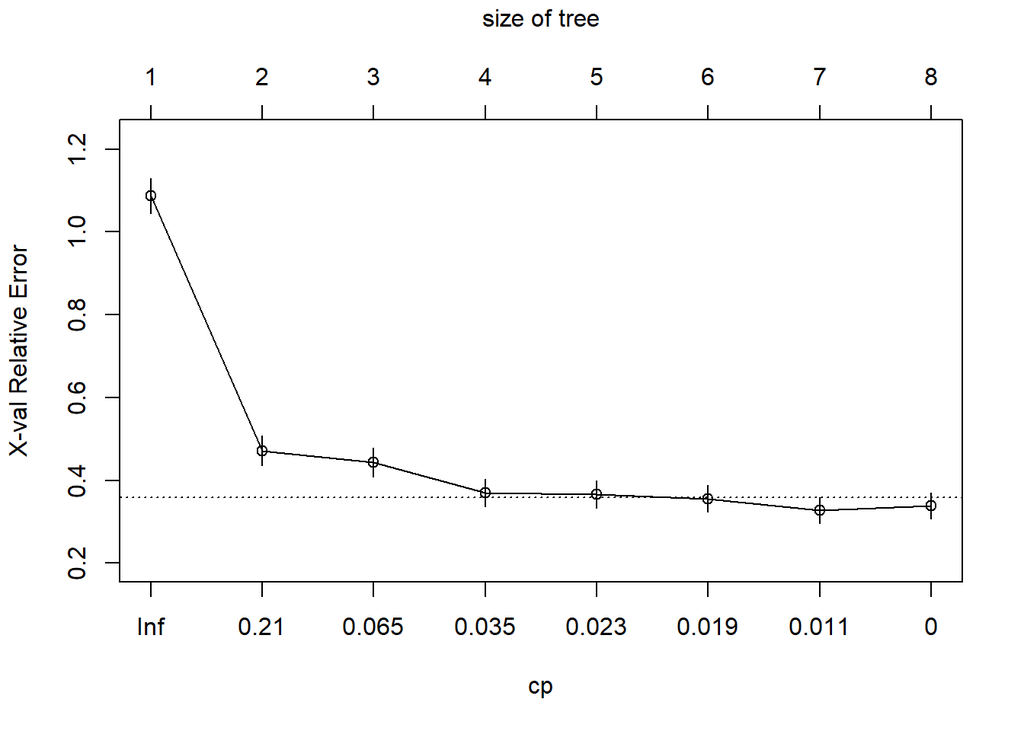

```r
best_cp <- best_tree_model$cptable[which.min(best_tree_model$cptable[,"xerror"]),"CP"]
plotcp(best_tree_model)
```

```r
# Teraz możemy przyciąć nasze drzewo
pruned_tree <- prune(best_tree_model, cp = best_cp)
print(pruned_tree)
```

```
## n= 576
##
## node), split, n, loss, yval, (yprob)
##       * denotes terminal node
##
##  1) root 576 284 0 (0.50694444 0.49305556)
##    2) STSlopeFlat< 0.5 310  76 0 (0.75483871 0.24516129)
##      4) ExerciseAngina>=0.5 250  34 0 (0.86400000 0.13600000)
##        8) Cholesterol>=119.5 224  18 0 (0.91964286 0.08035714) *
##        9) Cholesterol< 119.5 26  10 1 (0.38461538 0.61538462)
##         18) FastingBS< 0.5 15   5 0 (0.66666667 0.33333333) *
##         19) FastingBS>=0.5 11   0 1 (0.00000000 1.00000000) *
##      5) ExerciseAngina< 0.5 60  18 1 (0.30000000 0.70000000)
##       10) MaxHR>=157.5 11   2 0 (0.81818182 0.18181818) *
##       11) MaxHR< 157.5 49   9 1 (0.18367347 0.81632653) *
##    3) STSlopeFlat>=0.5 266  58 1 (0.21804511 0.78195489)
##      6) Sex< 0.5 44  15 0 (0.65909091 0.34090909) *
##      7) Sex>=0.5 222  29 1 (0.13063063 0.86936937) *
```

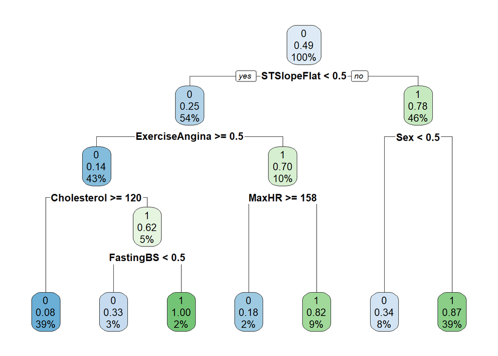

```r
rpart.plot(pruned_tree,roundint = FALSE)
```

```r
#testowanie przycietego drzewa na zbiorze treningowym
predicted3 <- predict(pruned_tree, newdata = train_set, type = "class")
confusionMatrix(predicted3, train_set$heartDisease)
```

```
## Confusion Matrix and Statistics
##
##           Reference
## Prediction   0   1
##          0 254  40
##          1  38 244
##
##                Accuracy : 0.8646
##                  95% CI : (0.8339, 0.8915)
##     No Information Rate : 0.5069
##     P-Value [Acc > NIR] : <2e-16
##
##                   Kappa : 0.7291
##
##  Mcnemar's Test P-Value : 0.9099
##
##             Sensitivity : 0.8699
##             Specificity : 0.8592
##          Pos Pred Value : 0.8639
##          Neg Pred Value : 0.8652
##              Prevalence : 0.5069
##          Detection Rate : 0.4410
##    Detection Prevalence : 0.5104
##       Balanced Accuracy : 0.8645
##
##        'Positive' Class : 0
##
```

```r
# Testowanie przyciętego drzewa na zbiorze testowym
predicted4 <- predict(pruned_tree, newdata = test_set, type = "class")
confusionMatrix(predicted4, test_set$heartDisease)
```

```
## Confusion Matrix and Statistics
##
##           Reference
## Prediction   0   1
##          0  95  19
##          1  23 105
##
##                Accuracy : 0.8264
##                  95% CI : (0.7727, 0.872)
##     No Information Rate : 0.5124
##     P-Value [Acc > NIR] : <2e-16
##
##                   Kappa : 0.6524
##
##  Mcnemar's Test P-Value : 0.6434
##
##             Sensitivity : 0.8051
##             Specificity : 0.8468
##          Pos Pred Value : 0.8333
##          Neg Pred Value : 0.8203
##              Prevalence : 0.4876
##          Detection Rate : 0.3926
##    Detection Prevalence : 0.4711
##       Balanced Accuracy : 0.8259
##
##        'Positive' Class : 0
##
```

W badaniu jak wybór kryterium podziału wpływa na uzyskiwane wyniki, zbadane zostały dwa przypadki dla reguł: indeks Giniego i entropia. Wyniki otrzymane dla zbiorów testowych dla parametru sensitivity dały nam dokładnie ten sam wynik. Wynosi 0,8051, co oznacza, że 80,51% prawdziwie pozytywnych przypadków zostało wykrytych. W celu decyzji, która reguła będzie lepsza zwracamy uwagę na parametry specificity i accuracy. Dla indeksu Giniego Specificity wynosi 0,8871, co oznacza, że 88,71% prawdziwie negatywnych przypadków zostało poprawnie sklasyfikowanych (dla entropii mniej 0,8468). Również wartość accuracy jest lepsza dla Indeksu Giniego. **Podsumowując, na podstawie tych wyników wydaje się, że wybór klasyfikatora opartego na indeksie Giniego może być lepszy dla tego konkretnego problemu klasyfikacji w porównaniu do klasyfikatora opartego na entropii.**

#### **Wybór parametrów, dla których naszym zdaniem uzyskano najlepsze drzewo.**

```r
#Hyperparameter Tuning training with mlr
getParamSet("classif.rpart")
```

```
##                    Type len  Def   Constr Req Tunable Trafo
## minsplit        integer   -   20 1 to Inf   -    TRUE     -
## minbucket       integer   -    - 1 to Inf   -    TRUE     -
## cp              numeric   - 0.01   0 to 1   -    TRUE     -
## maxcompete      integer   -    4 0 to Inf   -    TRUE     -
## maxsurrogate    integer   -    5 0 to Inf   -    TRUE     -
## usesurrogate   discrete   -    2    0,1,2   -    TRUE     -
## surrogatestyle discrete   -    0      0,1   -    TRUE     -
## maxdepth        integer   -   30  1 to 30   -    TRUE     -
## xval            integer   -   10 0 to Inf   -   FALSE     -
## parms           untyped   -    -        -   -    TRUE     -
```

```r
traintask <- mlr::makeClassifTask(
  data=train_set,
  target="heartDisease"
)
# Define Grid
control_grid = mlr::makeTuneControlGrid()
# Define Cross Validation
resample = makeResampleDesc("CV",iter = 5,predict = "both")
# Define Measure
measure = acc
learner <- mlr::makeLearner("classif.rpart", predict.type = "prob", parms = list(split = "gini"))

param_grid <- makeParamSet(
  makeDiscreteParam("maxdepth", values=2:7),
  makeDiscreteParam("cp", values = 0),
 makeDiscreteParam("minsplit", values=1:30),
  makeDiscreteParam('xval',value =10)
)
```

```r
dt_tuneparam_multi <- tuneParams(learner=learner,
                                 task=traintask,
                                 resampling = resample,
                                 measures = measure,
                                 par.set=param_grid,
                                 control=control_grid,
                                 show.info = TRUE)
```

```r
# Extracting best Parameters from Multi Search
best_params = setHyperPars(
  makeLearner("classif.rpart", predict.type = "prob"),
  par.vals = dt_tuneparam_multi$x
)

best_model_multi <- mlr::train(best_params, traintask)
best_tree_model <- best_model_multi$learner.model
rpart.plot(best_tree_model)
```

[output not shown]

```r
predicted2 <- predict(best_tree_model, newdata = test_set, type = "class")
confusionMatrix(predicted2, test_set$heartDisease)
```

```
## Confusion Matrix and Statistics
##
##           Reference
## Prediction   0   1
##          0  95  11
##          1  23 113
##
##                Accuracy : 0.8595
##                  95% CI : (0.8092, 0.9007)
##     No Information Rate : 0.5124
##     P-Value [Acc > NIR] : < 2e-16
##
##                   Kappa : 0.7181
##
##  Mcnemar's Test P-Value : 0.05923
##
##             Sensitivity : 0.8051
##             Specificity : 0.9113
##          Pos Pred Value : 0.8962
##          Neg Pred Value : 0.8309
##              Prevalence : 0.4876
##          Detection Rate : 0.3926
##    Detection Prevalence : 0.4380
##       Balanced Accuracy : 0.8582
##
##        'Positive' Class : 0
##
```

```r
probabilities <- predict(best_tree_model, newdata = test_set, type = "prob")[,2]
roc_obj <- roc(test_set$heartDisease, probabilities)
auc <- round(auc(test_set$heartDisease, probabilities),4)
#przycinanie
best_tree_model$cptable
```

```
##            CP nsplit rel error    xerror       xstd
## 1 0.528169014      0 1.0000000 1.1056338 0.04208098
## 2 0.084507042      1 0.4718310 0.5070423 0.03659262
## 3 0.049295775      2 0.3873239 0.4154930 0.03410705
## 4 0.024647887      3 0.3380282 0.3380282 0.03149392
## 5 0.021126761      4 0.3133803 0.3450704 0.03175392
## 6 0.017605634      5 0.2922535 0.3380282 0.03149392
## 7 0.007042254      6 0.2746479 0.3063380 0.03026108
## 8 0.000000000      7 0.2676056 0.2957746 0.02982584
```

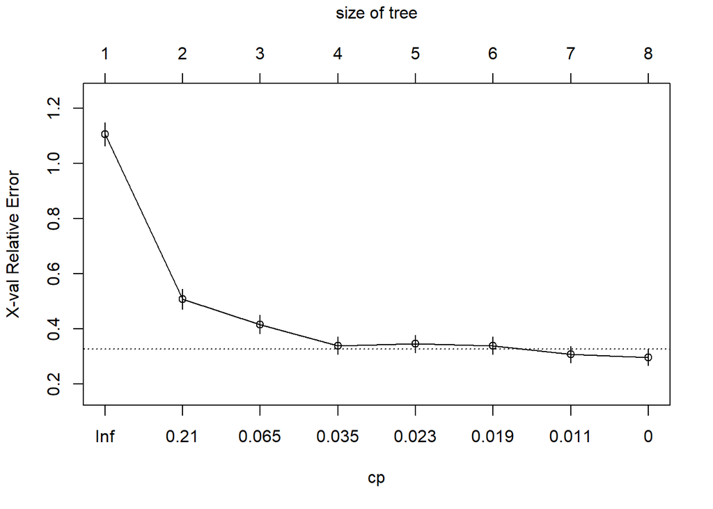

```r
best_cp <- best_tree_model$cptable[which.min(best_tree_model$cptable[,"xerror"]),"CP"]
plotcp(best_tree_model)
```

```r
# Teraz możemy przyciąć nasze drzewo
pruned_tree <- prune(best_tree_model, cp = best_cp)
print(pruned_tree)
```

```
## n= 576
##
## node), split, n, loss, yval, (yprob)
##       * denotes terminal node
##
##  1) root 576 284 0 (0.50694444 0.49305556)
##    2) STSlopeFlat< 0.5 310  76 0 (0.75483871 0.24516129)
##      4) ExerciseAngina>=0.5 250  34 0 (0.86400000 0.13600000)
##        8) Cholesterol>=119.5 224  18 0 (0.91964286 0.08035714) *
##        9) Cholesterol< 119.5 26  10 1 (0.38461538 0.61538462)
##         18) FastingBS< 0.5 15   5 0 (0.66666667 0.33333333) *
##         19) FastingBS>=0.5 11   0 1 (0.00000000 1.00000000) *
##      5) ExerciseAngina< 0.5 60  18 1 (0.30000000 0.70000000)
##       10) MaxHR>=157.5 11   2 0 (0.81818182 0.18181818) *
##       11) MaxHR< 157.5 49   9 1 (0.18367347 0.81632653) *
##    3) STSlopeFlat>=0.5 266  58 1 (0.21804511 0.78195489)
##      6) Sex< 0.5 44  15 0 (0.65909091 0.34090909)
##       12) ExerciseAngina>=0.5 26   5 0 (0.80769231 0.19230769) *
##       13) ExerciseAngina< 0.5 18   8 1 (0.44444444 0.55555556) *
##      7) Sex>=0.5 222  29 1 (0.13063063 0.86936937) *
```

```r
rpart.plot(pruned_tree,roundint = FALSE)
```

[output not shown]

```r
#testowanie przycietego drzewa na zbiorze treningowym
predicted3 <- predict(pruned_tree, newdata = train_set, type = "class")
confusionMatrix(predicted3, train_set$heartDisease)
```

```
## Confusion Matrix and Statistics
##
##           Reference
## Prediction   0   1
##          0 246  30
##          1  46 254
##
##                Accuracy : 0.8681
##                  95% CI : (0.8377, 0.8946)
##     No Information Rate : 0.5069
##     P-Value [Acc > NIR] : < 2e-16
##
##                   Kappa : 0.7363
##
##  Mcnemar's Test P-Value : 0.08532
##
##             Sensitivity : 0.8425
##             Specificity : 0.8944
##          Pos Pred Value : 0.8913
##          Neg Pred Value : 0.8467
##              Prevalence : 0.5069
##          Detection Rate : 0.4271
##    Detection Prevalence : 0.4792
##       Balanced Accuracy : 0.8684
##
##        'Positive' Class : 0
##
```

```r
# Testowanie przyciętego drzewa na zbiorze testowym
predicted4 <- predict(pruned_tree, newdata = test_set, type = "class")
cmtree <- confusionMatrix(predicted4, test_set$heartDisease)
cmtree
```

```
## Confusion Matrix and Statistics
##
##           Reference
## Prediction   0   1
##          0  95  11
##          1  23 113
##
##                Accuracy : 0.8595
##                  95% CI : (0.8092, 0.9007)
##     No Information Rate : 0.5124
##     P-Value [Acc > NIR] : < 2e-16
##
##                   Kappa : 0.7181
##
##  Mcnemar's Test P-Value : 0.05923
##
##             Sensitivity : 0.8051
##             Specificity : 0.9113
##          Pos Pred Value : 0.8962
##          Neg Pred Value : 0.8309
##              Prevalence : 0.4876
##          Detection Rate : 0.3926
##    Detection Prevalence : 0.4380
##       Balanced Accuracy : 0.8582
##
##        'Positive' Class : 0
##
```

```r
#sprawdzenie ktora zmienna ma najwieksze znaczenie
importance <- varImp(pruned_tree)
print(importance)
```

```
##                    Overall
## Age               10.94259
## ChestPainTypeASY 126.40718
## Cholesterol       40.73838
## ExerciseAngina   113.59324
## FastingBS         16.93147
## MaxHR             72.52941
## Oldpeak          100.91443
## Sex               24.24908
## STSlopeDown       29.68648
## STSlopeFlat       82.50219
```

```r
#do wykresu
probabilities <- predict(pruned_tree, newdata = test_set, type = "prob")[,2]
roc_obj <- roc(test_set$heartDisease, probabilities)
auc <- round(auc(test_set$heartDisease, probabilities),4)
```

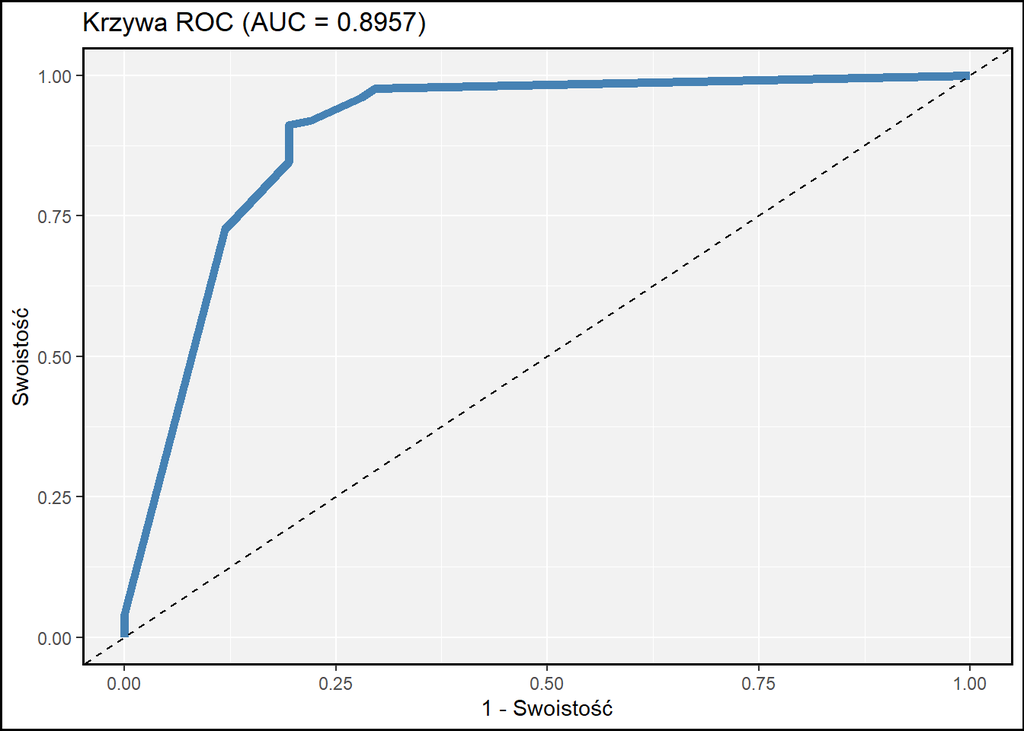

```r
# Rysowanie krzywej ROC
ggroc(roc_obj,colour = 'steelblue',size=2,legacy.axes = TRUE) +
  geom_abline(linetype = "dashed") +
  theme(panel.border = element_rect(color = 'black',fill = NA,size = 1),
        panel.background = element_rect(fill='gray95'),
        plot.background = element_rect(color = 'black', size = 1)
  )+
  ggtitle(paste0('Krzywa ROC ', '(AUC = ', auc, ')')) +
  labs(x = "1 - Swoistość",
       y = "Swoistość")
```

# **3. Zastosowanie rozszerzenia drzew decyzyjnych - bagging.**

#### **Zweryfikować jak liczba wykorzystywanych drzew wpływa na uzyskiwane wyniki.**

```r
dane <-  read.csv("Heart2.csv", sep=";")
dane$heartDisease <- as.factor(dane$heartDisease)
# Podział danych
set.seed(123)
ind <- sample(2, nrow(dane), replace = TRUE, prob = c(0.7, 0.3))
train_set <- dane[ind==1,]
test_set <- dane[ind==2,]

mfinal_values <- c(50, 100, 150,200,250)

results <- list()

for (mfinal in mfinal_values) {
  model <- bagging(heartDisease ~ ., data = train_set, mfinal = mfinal)
  pred <- predict.bagging(model, newdata = test_set)
  pred1 <- as.factor(pred$class)
  cm <- confusionMatrix(pred1, test_set$heartDisease)

  results[[as.character(mfinal)]] <- list(mfinal = mfinal, cm = cm)
}

# Znajdź najlepszy model
best_mfinal <- mfinal_values[which.max(sapply(results, function(x) x$cm$overall["Accuracy"]))]
best_model <- results[[as.character(best_mfinal)]]

# Wyświetlenie wyników
print(best_model$cm)
```

```
## Confusion Matrix and Statistics
##
##           Reference
## Prediction   0   1
##          0  99  12
##          1  19 112
##
##                Accuracy : 0.8719
##                  95% CI : (0.8231, 0.9113)
##     No Information Rate : 0.5124
##     P-Value [Acc > NIR] : <2e-16
##
##                   Kappa : 0.7433
##
##  Mcnemar's Test P-Value : 0.2812
##
##             Sensitivity : 0.8390
##             Specificity : 0.9032
##          Pos Pred Value : 0.8919
##          Neg Pred Value : 0.8550
##              Prevalence : 0.4876
##          Detection Rate : 0.4091
##    Detection Prevalence : 0.4587
##       Balanced Accuracy : 0.8711
##
##        'Positive' Class : 0
##
```

```r
print("Najlepsza wartość mfinal:")
```

```
## [1] "Najlepsza wartość mfinal:"
```

```r
print(best_model$mfinal)
```

```
## [1] 200
```

W naszym przypadku najlepsze wyniki otrzymaliśmy dla wartości 200 drzew, otrzymując dokładność na poziomie 0,8719 i wartość sensitivity na poziomie 0,8390, co jest logicznym zdarzeniem, gdyż można przypuszczać, że wraz z wzrostem liczby drzew wyniki powinny być lepsze, lecz może to powodować znaczne zwiększenie czasu potrzebnego do wykonania obliczeń.

#### **Weryfikacja jak zmiana liczby obserwacji wykorzystywanych do budowy jednego drzewa wpływa na uzyskiwane wyniki.**

Nie potrafiliśmy znaleźć funkcji w dla metody baggingu która by posiadała argument do zmiany liczby obserwacji wykorzystywanych do budowy drzewa, można by to zrobić ręcznie ale nie jesteśmy pewni czy to by działało w taki sam sposób.

#### **Wybór parametrów, dla których naszym zdaniem uzyskano najlepsze wyniki po zastosowaniu baggingu.**

```r
param_grid <- expand.grid(iterations = c(50, 100, 150,200),
                          maxdepth = c(3,5,7,10),
                          minsplit = c(5,10,15,20,25))

results <- list()
# Przeszukiwanie siatki parametrów
for (i in 1:nrow(param_grid)) {
  iterations <- param_grid$iterations[i]
  maxdepth <- param_grid$maxdepth[i]
  minsplit <- param_grid$minsplit[i]

  model <- bagging(heartDisease ~ ., data = train_set, mfinal = iterations,
                   control = rpart.control(maxdepth = maxdepth, minsplit = minsplit))

  pred <- predict.bagging(model, newdata = test_set)
  pred1 <- as.factor(pred$class)

  cm <- confusionMatrix(pred1, test_set$heartDisease)

  results[[i]] <- list(iterations = iterations, maxdepth = maxdepth, minsplit = minsplit, cm = cm)
}

# Znajdź najlepszy model
best_model <- results[[which.max(sapply(results, function(x) x$cm$overall["Accuracy"]))]]

# Wyświetlenie wyników
print(best_model$cm)
```

```
## Confusion Matrix and Statistics
##
##           Reference
## Prediction   0   1
##          0  98   8
##          1  20 116
##
##                Accuracy : 0.8843
##                  95% CI : (0.8371, 0.9217)
##     No Information Rate : 0.5124
##     P-Value [Acc > NIR] : < 2e-16
##
##                   Kappa : 0.7679
##
##  Mcnemar's Test P-Value : 0.03764
##
##             Sensitivity : 0.8305
##             Specificity : 0.9355
##          Pos Pred Value : 0.9245
##          Neg Pred Value : 0.8529
##              Prevalence : 0.4876
##          Detection Rate : 0.4050
##    Detection Prevalence : 0.4380
##       Balanced Accuracy : 0.8830
##
##        'Positive' Class : 0
##
```

```r
print(best_model$iterations)
```

```
## [1] 50
```

```r
print(best_model$maxdepth)
```

```
## [1] 3
```

```r
print(best_model$minsplit)
```

```
## [1] 10
```

# **4. Porównianie wyników uzyskanych za pomocą prostego drzewa decyzyjnego oraz baggingu. Wskazanie wad i zalet.**

```r
#najlepszy model drzewa decyzyjne
print(cmtree)
```

```
## Confusion Matrix and Statistics
##
##           Reference
## Prediction   0   1
##          0  95  11
##          1  23 113
##
##                Accuracy : 0.8595
##                  95% CI : (0.8092, 0.9007)
##     No Information Rate : 0.5124
##     P-Value [Acc > NIR] : < 2e-16
##
##                   Kappa : 0.7181
##
##  Mcnemar's Test P-Value : 0.05923
##
##             Sensitivity : 0.8051
##             Specificity : 0.9113
##          Pos Pred Value : 0.8962
##          Neg Pred Value : 0.8309
##              Prevalence : 0.4876
##          Detection Rate : 0.3926
##    Detection Prevalence : 0.4380
##       Balanced Accuracy : 0.8582
##
##        'Positive' Class : 0
##
```

```r
#najlepszy model bagging
print(best_model$cm)
```

```
## Confusion Matrix and Statistics
##
##           Reference
## Prediction   0   1
##          0  98   8
##          1  20 116
##
##                Accuracy : 0.8843
##                  95% CI : (0.8371, 0.9217)
##     No Information Rate : 0.5124
##     P-Value [Acc > NIR] : < 2e-16
##
##                   Kappa : 0.7679
##
##  Mcnemar's Test P-Value : 0.03764
##
##             Sensitivity : 0.8305
##             Specificity : 0.9355
##          Pos Pred Value : 0.9245
##          Neg Pred Value : 0.8529
##              Prevalence : 0.4876
##          Detection Rate : 0.4050
##    Detection Prevalence : 0.4380
##       Balanced Accuracy : 0.8830
##
##        'Positive' Class : 0
##
```

Porownujac wyniki otrzymane w wyniku algorytmu drzewa decyzyjnego i baggingu mozna stwierdzic, ze w przypadku naszego zestawu danych lepiej działa algorytm baggingu, ktory osiagnał lepsze wyniki w dokladnosci(0.8595 do 0.8843) swoistosci(0.9113 do 0.9355) i czułosci(0.8051 do 0.8305).

### Proste drzewo decyzyjne:

**Zalety:**

1.**Prostota interpretacji**: Proste drzewa decyzyjne są intuicyjne i łatwe do zrozumienia. Mogą być używane do wyjaśnienia decyzji podejmowanych przez model, co jest ważne w przypadku zrozumienia procesu podejmowania decyzji.

2.**Przechwytywanie interakcji między zmiennymi**: Drzewa decyzyjne mogą skutecznie wykrywać i modelować interakcje między zmiennymi wejściowymi, co jest trudniejsze do osiągnięcia w niektórych innych modelach.

3.**Odporność na dane o niskiej jakości**: Drzewa decyzyjne potrafią radzić sobie z danymi zawierającymi braki, a także z danymi nieliniowymi i niemonotonicznymi.

**Wady:**

1.**Skłonność do przetrenowania**: Proste drzewa decyzyjne mają tendencję do tworzenia zbyt złożonych modeli, które doskonale dopasowują się do danych treningowych, co może prowadzić do przetrenowania.

2.**Nieefektywność w rozwiązywaniu bardziej skomplikowanych problemów**: Proste drzewa decyzyjne mogą być niewystarczające w bardziej skomplikowanych zadaniach klasyfikacji lub regresji, gdzie struktura danych jest bardziej złożona.

### Bagging:

**Zalety:**

1.**Redukcja wariancji**: Bagging polega na łączeniu wielu modeli (np. drzew decyzyjnych) w celu zmniejszenia wariancji. Działa dobrze w przypadku modeli, które są skłonne do przetrenowania, co prowadzi do lepszych wyników na zbiorze testowym.

2.**Ogólna wydajność**: Bagging może poprawić ogólną wydajność modelu poprzez wygładzenie wyników i poprawę stabilności.

3.**Zwiększenie tolerancji na szum w danych**: Bagging może pomóc w radzeniu sobie z szumem w danych, ponieważ agregowanie wyników wielu modeli pomaga w redukcji wpływu odstających obserwacji.

**Wady:**

1.**Strata interpretowalności**: Bagging utrudnia interpretację modelu, ponieważ jest to połączenie wielu mniejszych modeli. Skomplikowane modele ensemble są trudniejsze do zrozumienia.

2.**Wymagana większa ilość danych i zasobów obliczeniowych**: Bagging wymaga trenowania wielu modeli, co może być bardziej czasochłonne i wymaga więcej zasobów obliczeniowych w porównaniu do pojedynczego drzewa decyzyjnego.

Podsumowując, zarówno proste drzewa decyzyjne, jak i bagging mają swoje miejsce w narzędziach uczenia maszynowego, a wybór między nimi zależy od konkretnego problemu, dostępnych zasobów i preferencji interpretacyjnych. Bagging jest szczególnie przydatny w przypadku modeli o dużej wariancji, podczas gdy proste drzewo decyzyjne może być stosowane w prostszych zadaniach lub tam, gdzie interpretowalność modelu jest priorytetem.